# The Shape of Digits

A Bayesian Topological Data Analytic Approach to Classification of Handwritten Digits

Thomas Reinke

[Baylor University](https://www.baylor.edu)

Theophilus A. Bediako

[Baylor University](https://www.baylor.edu)

Daniel Lim

[Baylor University](https://www.baylor.edu)

August 14, 2025

# Contents

1. MNIST EDA
2. Tradiotional ML
3. Proposed Methodology
4. Analysis
5. TDA + ML
6. Results/Future Work
7. References

# Exploratory Data Analysis

## Distribution of training labels

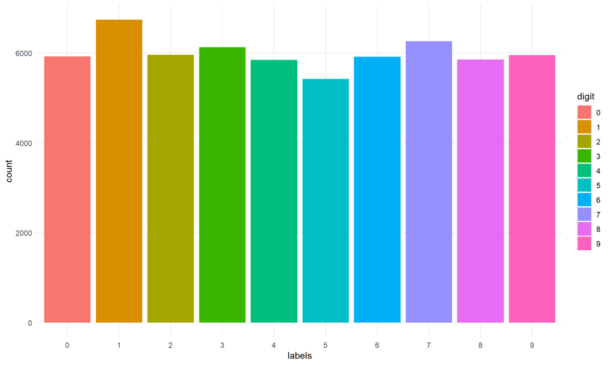

## Pixel Intensity

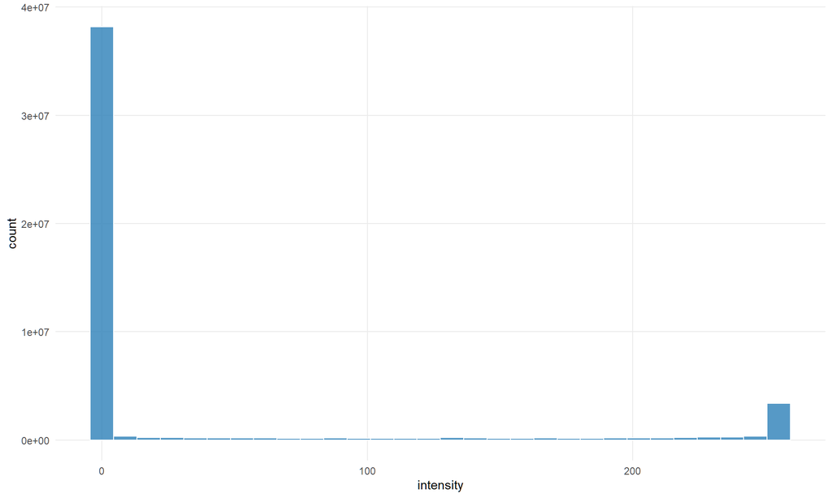

## Training Data tSNE Visualization

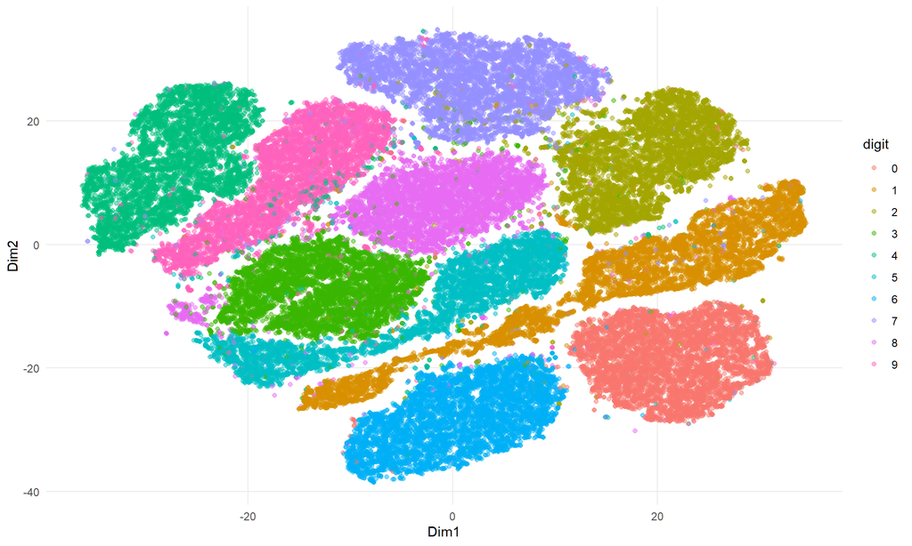

# Traditional ML

## Neural networks

Feedforward neural network with structure:

- Input layer: Consists of neurons that receives the input data. Each neuron in the input layer represents a feature of the input data
- Hidden layer: One or more hidden layers placed between the input and output layers, responsible for capturing complex patterns
- Output layer: Final output of the network; Number of neurons represents the number of digits

## NN with regularization

- Depending on model, # network weights > size of training data
  - This leads to overfitting
- We considered two approaches to overfitting:
  - Dropout learning: Like RF, randomly removes fraction of units in layer during model fitting
  - Regularization: Impose penalties on parameters like lasso, ridge, etc.

## Specific NN models considered

- NN with dropout regularization
- NN with ridge regularization
- NN with lasso regularization

## Multinomial logistic regression

- Multinomial logistic regression equivalently represented by NN with no hidden layers
- Output layer with softmax
  - $f_m(X) = Pr(Y = m | X) = \frac{e^{Z_m}}{\sum_\limits{l \in K}e^{Z_l}}$

## NN Fitting

- Train the network for 30 epochs with a batch size of 128
  - SGD updates weights for each batch
- Images are presented in batches of 128, and SGD updates weights after each batch
- Each epoch processes all 60,000 training images
- Classification correct if largest output value matches target label

# Proposed Methodology

## TDA Workflow

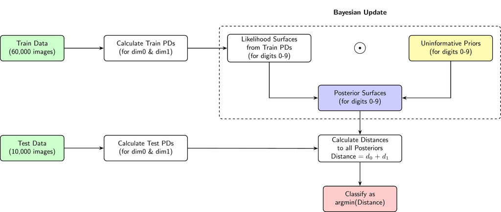

# Analysis

## Confusion Matrix Heatmap - NN dropout

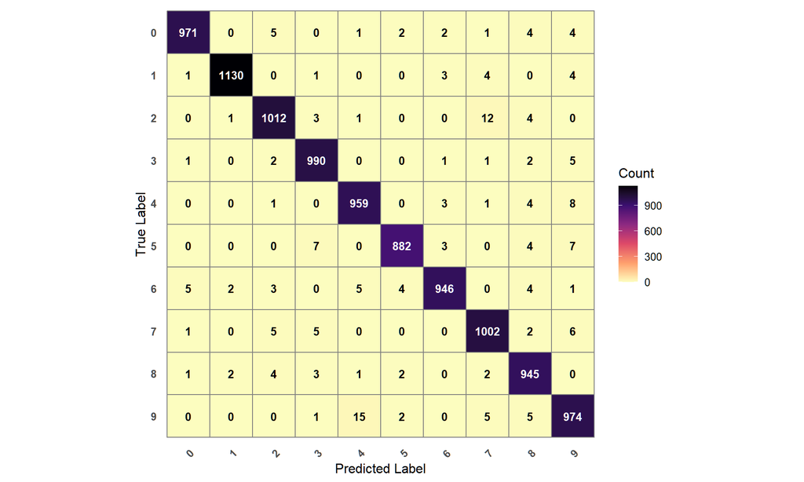

## Confusion Matrix Heatmap - NN ridge

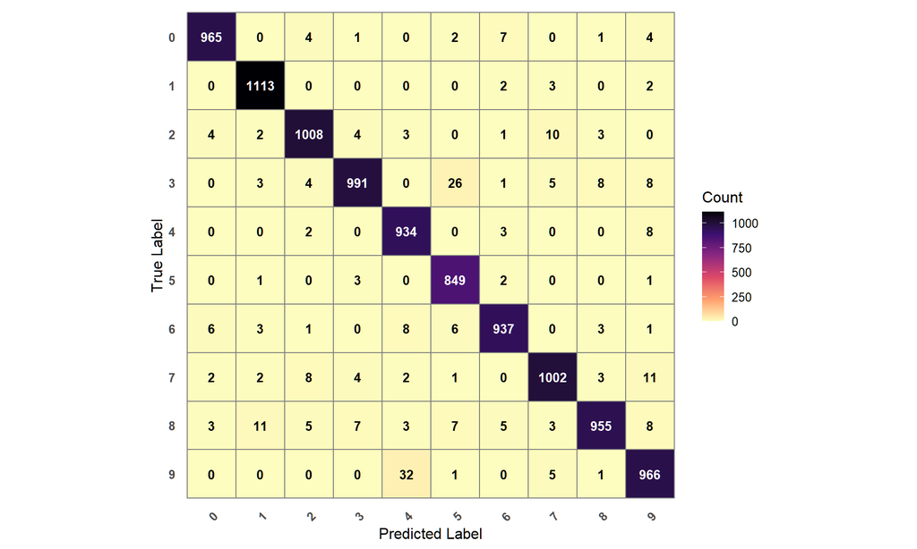

## Confusion Matrix Heatmap - Multinomial

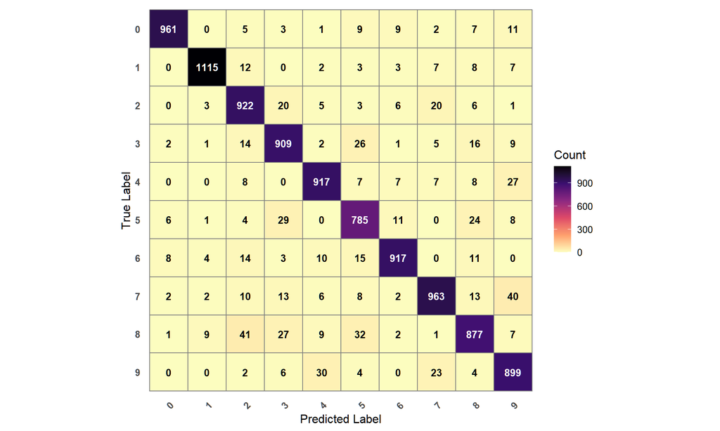

## Proposed Method Analysis

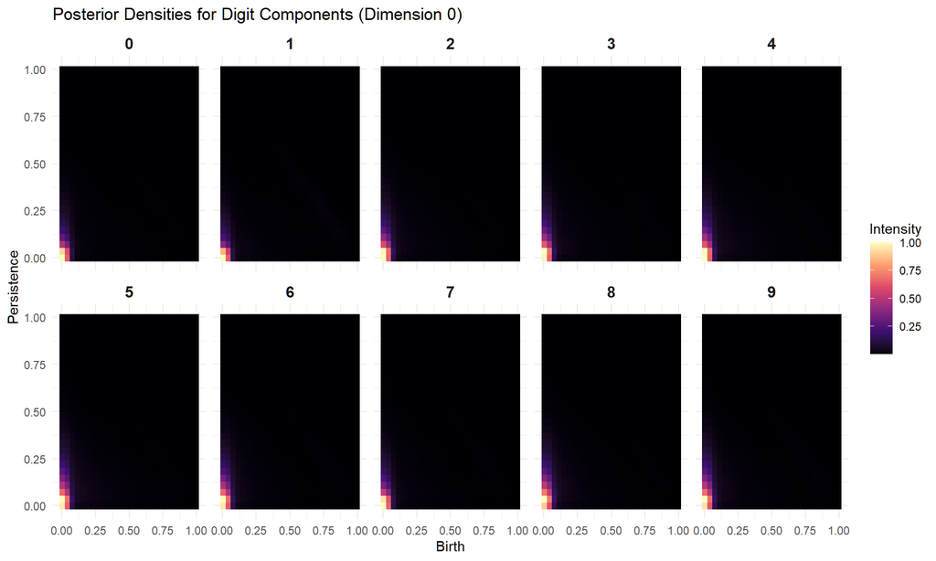

## Proposed Method Analysis

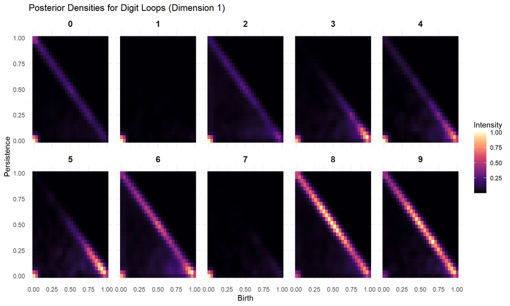

## Proposed Method Analysis

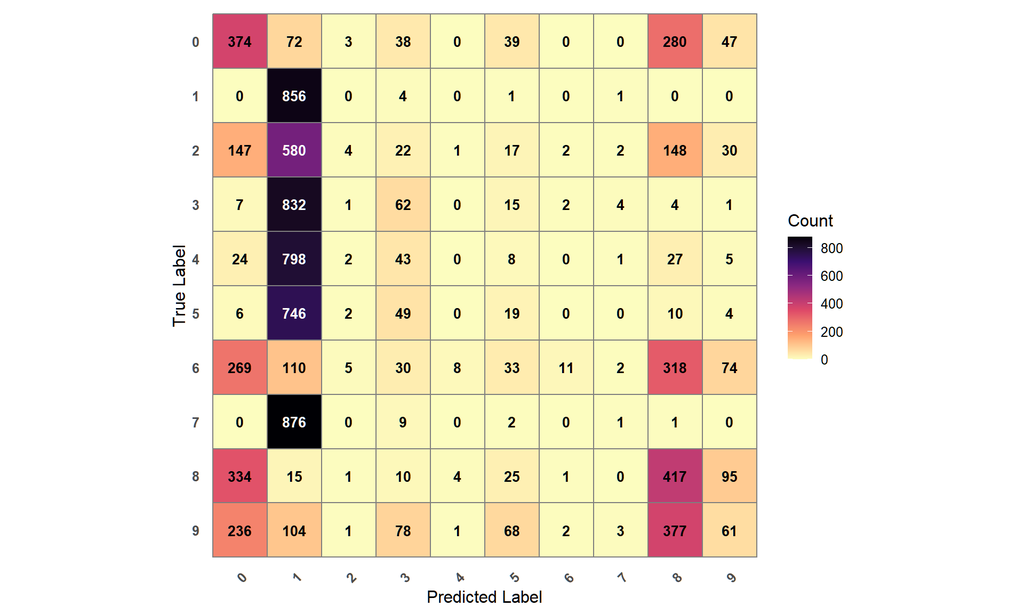

## Proposed Method Analysis

[output not shown]

# TDA + ML

## Filtering

- Grayscale: The most natural filtration, using the image’s original pixel intensities directly. Pixels are included in the complex as their intensity value passes a growing threshold.
- Height: Inspired by Morse theory, this filtration assigns a value to each pixel based on its projection onto a chosen direction vector, essentially measuring its “height” from a specific angle. Your code uses 8 different directions to capture features from multiple perspectives.
- Radial: Assigns a value to each pixel based on its distance from a chosen center point. Your code uses 9 different centers to capture features originating from various locations.
- Dilation: Assigns each pixel a value corresponding to its shortest distance to a foreground (value=1) pixel. This has the effect of “growing” or “dilating” the digit.
- Erosion: The inverse of dilation. It’s achieved by applying the dilation filtration to the inverted image. This “shrinks” or “erodes” the digit.
- Density: Assigns each pixel a value based on the number of foreground neighbors within a given radius. Your code uses radii of 2, 4, and 6 to capture line thickness at different scales.

## Filtering

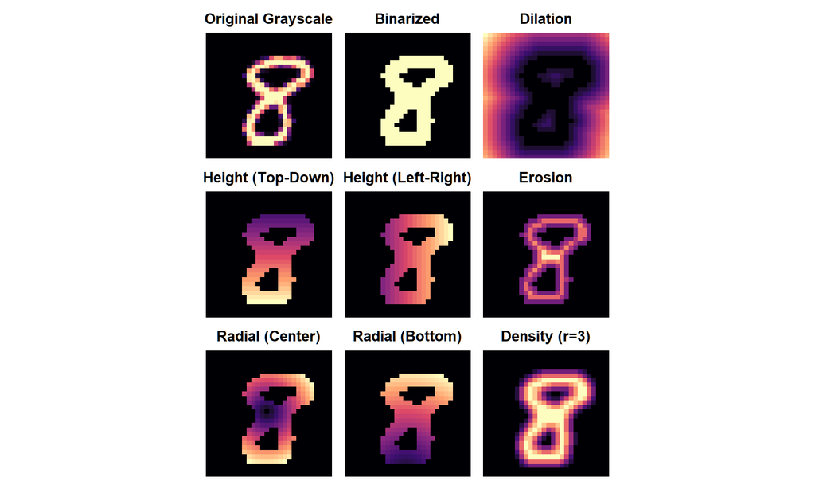

## Analysis

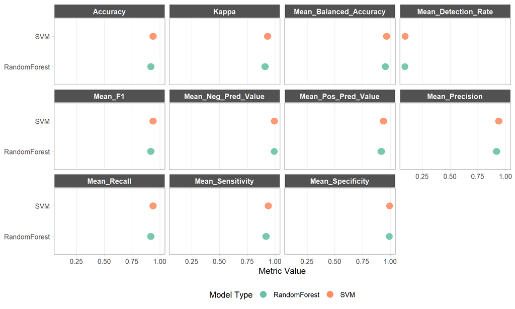

## Analysis

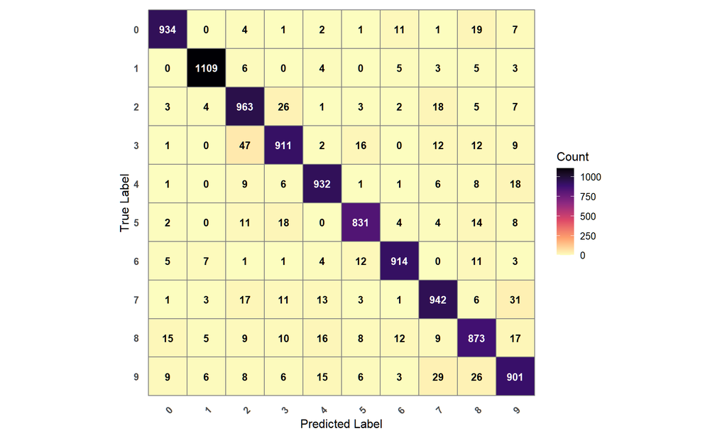

## Analysis

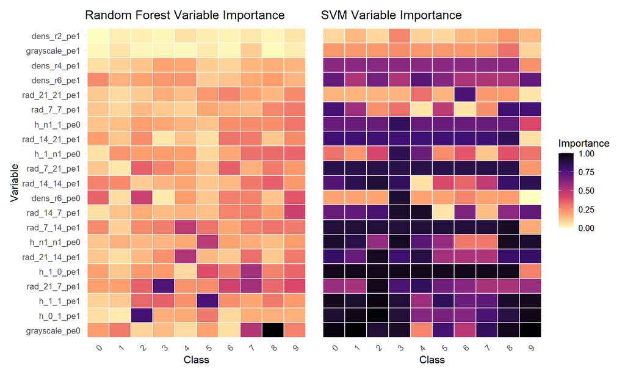

# Results/Future Work

# References

## References